# Confidence Intervals Class Worksheet

Created by Jill E. Thomley

Tuesday, April 13, 2021 @ 11:58 AM

### Packages Used

```r
library(HistData)
library(resampledata)
library(tidyverse)
library(moments)
library(infer)
```

### Michelson’s Light Speed Data

Albert Michelson (1852–1931) was an American physicist known for his work on measuring the speed of light. He was the first American to win the Nobel Prize for science (1907). The `Michelson` dataset from the `HistData` package contains Michelson’s measurements of the velocity of light in air, made which he made from June 5 to July 2, 1879 and reported in Michelson (1882). The data values + 299,000 are Michelson’s measurements in km/sec. The currently accepted value of the speed of light in air is 299,702.547 km/sec.

Michelson, A. A. (1882). “Experimental determination of the velocity of light made at the United States Naval Academy, Anapolis”. *Astronomical Papers*, 1,109-145, U. S. Nautical Almanac Office.

```r
glimpse(Michelson)
```

```
Rows: 100
Columns: 1
$ velocity <int> 850, 740, 900, 1070, 930, 850, 950, 980, 980, 880, 1000, 980,…
```

#### Exploratory Data Analysis

##### Mean, SD, Sample Size

```r
# summary stats
velocity_summaries <- Michelson %>%
  summarize(n = n(),
            xbar = mean(velocity),
            s    = sd(velocity))
velocity_summaries
```

```
    n  xbar        s
1 100 852.4 79.01055
```

##### Histogram and Boxplot

Looks like it might be a bell. It’s unimodal. The left tail might be a little longer.

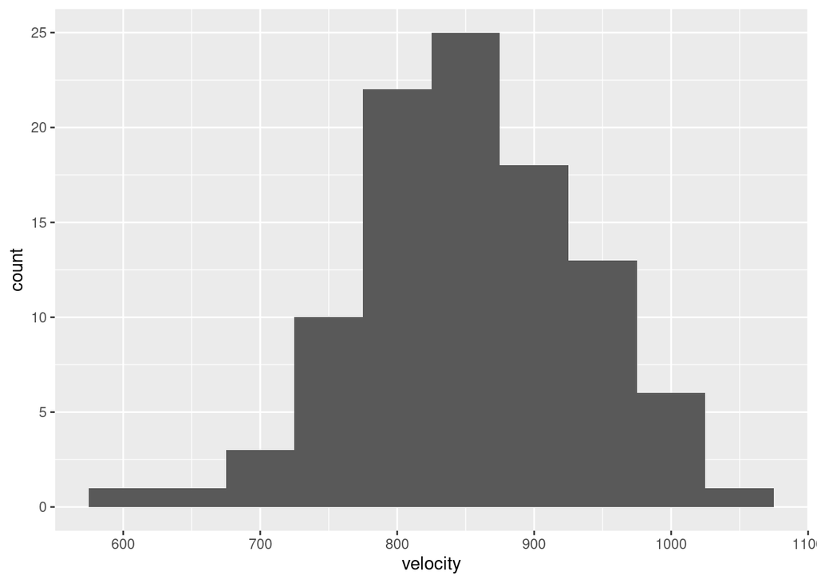

```r
# histogram
ggplot(Michelson, aes(x = velocity)) +
  geom_histogram(bins = 10)
```

It looks roughly symmatric, but we do have 3 (at least) outliers.

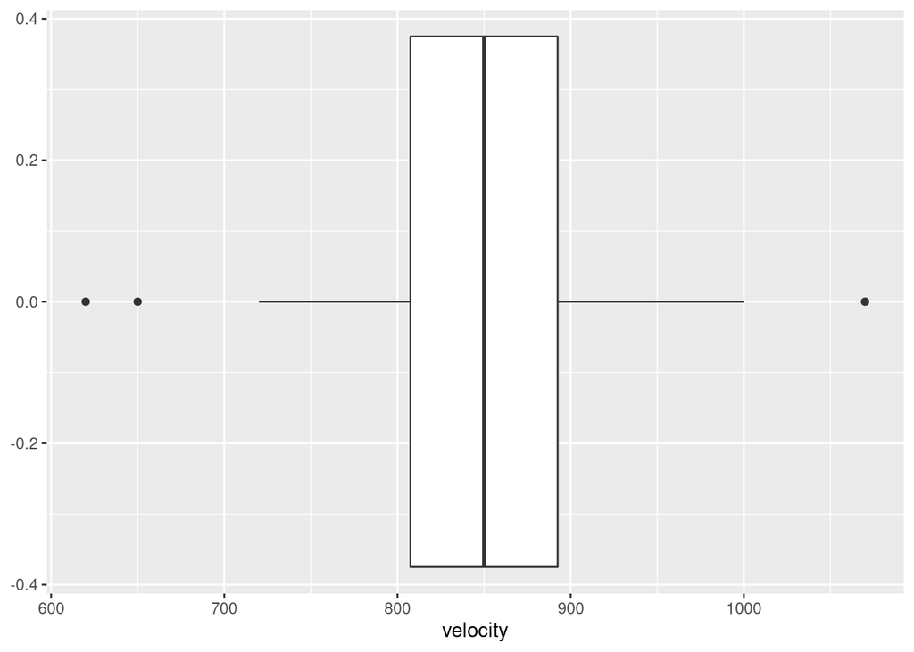

```r
# boxplot
ggplot(Michelson, aes(x = velocity)) +
  geom_boxplot()
```

##### Normal QQ Plot & Stats

The points are close to the line. The distribution might be a little thick-tailed.

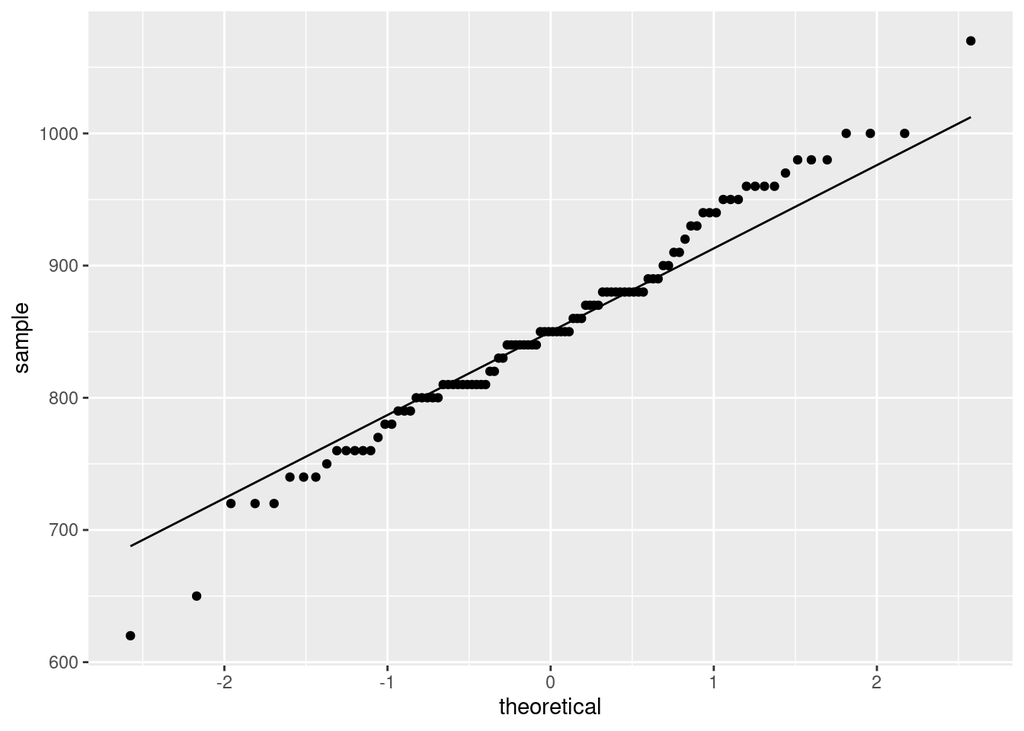

```r
# normal QQ plot
ggplot(Michelson, aes(sample = velocity)) +
  geom_qq() +
  geom_qq_line()
```

perfect symmetry = skewness of zero left skew = negative skewness right skew = positive skewness

rough rule of thumb, if skewness is between -0.5 and +0.5, it’s pretty symmetric

kurtosis is the “peakiness”

kurtosis of the normal distirbution is 3.

pointier than a bell with fat tails > 3

flatter than a bell with stumpy tails < 3

sometimes we subtract 3 from kurtosis so that the normal curve is 0

```r
# skewness and kurtosis
# from moments package
Michelson %>%
  summarize(skew = skewness(velocity),
            kurt = kurtosis(velocity),
            adj_kurt = kurt - 3)
```

```
         skew     kurt  adj_kurt
1 -0.01825961 3.263531 0.2635305
```

We have something that is symmetric but a little pointier with thicker tails than the bell curve.

#### Estimate Speed of Light

Estimate the speed of light in air using the mean of the measurements.

```r
# bootstrap percentile interval

# generate the multiple resamples to make the distribution
bootstrap_distribution <-
  Michelson %>%
  specify(response = velocity) %>%    # what variable(s)
  generate(reps = 1000, type = "bootstrap") %>%     # how to do the sim
  calculate(stat = "mean")    # what stat do we want?

# from the simulation, calculate the CI we want
percentile_ci <-
  bootstrap_distribution %>%
  get_confidence_interval(level = 0.95, type = "percentile")
percentile_ci
```

```
# A tibble: 1 x 2
  lower_ci upper_ci
     <dbl>    <dbl>
1     837.     868.
```

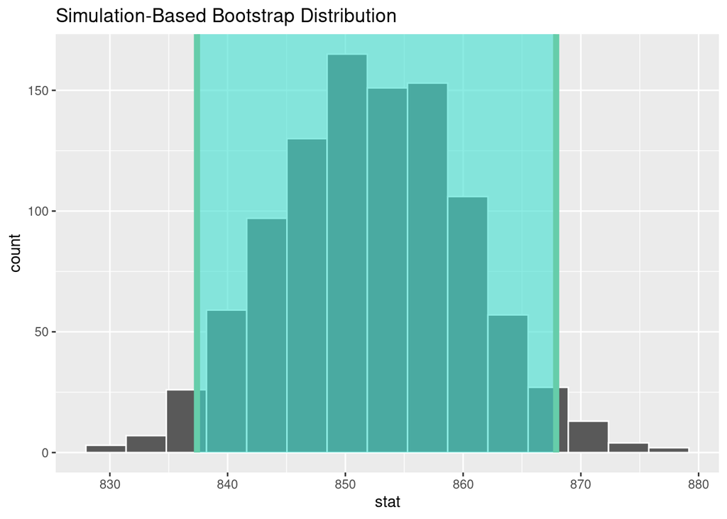

```r
visualize(bootstrap_distribution) +
  shade_ci(endpoints = percentile_ci)
```

```r
# bootstrap standard error interval (if appropriate)
# this one also assumes the bootstrap dist. is approx normal

standard_error_ci <- bootstrap_distribution %>%
  get_confidence_interval(level = 0.95, type = "se", point_estimate = velocity_summaries$xbar)
standard_error_ci
```

```
# A tibble: 1 x 2
  lower_ci upper_ci
     <dbl>    <dbl>
1     837.     868.
```

```r
# traditional confidence interval (if appropriate)
# assumes normally distributed population OR a large sample
# so that the sampling distribution is approx normal
# also independent random sample
# we can see from our plot that our bootstrap distribution is about normal
# so the two methods produce almost identical results

t.test(Michelson$velocity)
```

```
    One Sample t-test

data:  Michelson$velocity
t = 107.88, df = 99, p-value < 2.2e-16
alternative hypothesis: true mean is not equal to 0
95 percent confidence interval:
 836.7226 868.0774
sample estimates:
mean of x
    852.4
```

### Bangladesh Well Data

Bangladesh has suffered the largest population-level poisoning in history. Millions of people were exposed to naturally-occurring arsenic from tube-wells. Ironically, the wells had been installed to provide cleaner water than surface sources in order to reduce gastrointestinal diseases. Studies in other countries with long-term exposure to arsenic in groundwater found that 1 in 10 people who consume water containing 500 micrograms of arsenic per liter (mcg/l) may ultimately die from cancers caused by arsenic. The `Bangladesh` dataset from the textbook *Mathematical Statistics with Resampling and R* (found in the `resampledata` package) contains a sample of tested wells.

```r
glimpse(Bangladesh)
```

```
Rows: 271
Columns: 3
$ Arsenic  <dbl> 2400, 6, 904, 321, 1280, 151, 141, 1050, 511, 688, 81, 8, 37,…
$ Chlorine <dbl> 6.2, 116.0, 14.8, 35.9, 18.9, 7.8, 56.3, 16.0, 40.4, 29.3, 31…
$ Cobalt   <dbl> 0.42, 0.45, 0.63, 0.68, 0.58, 0.35, 0.46, 0.59, 0.48, 0.87, 0…
```

#### Exploratory Data Analysis

##### Mean, SD, Sample Size

```r
# summary stats
```

##### Histogram and Boxplot

```r
# histogram
```

```r
# boxplot
```

##### Normal QQ Plot & Stats

```r
# normal QQ plot
```

```r
# skewness and kurtosis
```

#### Estimate Mean Arsenic

Estimate the mean level of arsenic in Bangladesh tube wells.

```r
# bootstrap percentile interval
```

```r
# bootstrap standard error interval (if appropriate)
```

```r
# traditional confidence interval (if appropriate)
```

Estimate the true proportion of wells that exceed 500 mcg/l.

```r
# bootstrap percentile interval
```

```r
# bootstrap standard error interval (if appropriate)
```

#### Estimate Proportion #2

The maximum level of arsenic permitted in wells in Bangladesh is 50 mcg/l. Estimate the true proportion of wells that exceed this legal limit.

```r
# bootstrap percentile interval
```

```r
# bootstrap standard error interval (if appropriate)
```

#### Estimate Proportion #3

World Health Organization (WHO) recommends that wells contain no more than 10 mcg/l of arsenic. Estimate the true proportion of wells that exceed this limit.

```r
# bootstrap percentile interval
```

```r
# bootstrap standard error interval (if appropriate)
```

#### Question / Discussion

There are about 5 million tube wells in Bangladesh (serving many millions of people). How many wells are potentially impacted by high levels of arsenic?